# lab06_simulation

### Lab 6: Simulation

*Elements of Data Science*  
Welcome to Module 2 and lab 6! This week, we will go over conditionals and iteration, and introduce the concept of randomness. All of this material is covered in [Chapter 9](https://inferentialthinking.com/chapters/09/Randomness.html) and [Chapter 10](https://inferentialthinking.com/chapters/10/Sampling_and_Empirical_Distributions.html) of the online *Inferential Thinking* textbook.

First, set up the tests and imports by running the cell below.

```python
name = "Hannah"
name
```

```
'Hannah'
```

```python
## import statements
from gofer.ok import check
import numpy as np
from datascience import *
import matplotlib
%matplotlib inline
import matplotlib.pyplot as plt
plt.style.use('fivethirtyeight')
# Fix for datascience plots
import collections as collections
import collections.abc as abc
collections.Iterable = abc.Iterable
```

## 1. Sampling

#### 1.1 Dungeons and Dragons and Sampling

In the game Dungeons & Dragons, each player plays the role of a fantasy character. A player performs actions by rolling a 20-sided die, adding a "modifier" number to the roll, and comparing the total to a threshold for success. The modifier depends on her character's competence in performing the action. For example, suppose Alice's character, a barbarian warrior named Roga, is trying to knock down a heavy door. She rolls a 20-sided die, adds a modifier of 11 to the result (because her character is good at knocking down doors), and *succeeds if the total is greater than 15*.  
A Medium posting discusses probability in the context of Dungeons and Dragons https://towardsdatascience.com/understanding-probability-theory-with-dungeons-and-dragons-a36bc69aec88

[figure not shown]

**Question 1.1** Write code that simulates that procedure. Compute three values: the result of Alice's roll (roll_result), the result of her roll plus Roga's modifier (modified_result), and a boolean value indicating whether the action succeeded (action_succeeded). Do not fill in any of the results manually; the entire simulation should happen in code. Hint: A roll of a 20-sided die is a number chosen uniformly from the array make_array(1, 2, 3, 4, ..., 20). So a roll of a 20-sided die plus 11 is a number chosen uniformly from that array, plus 11.

```python
possible_rolls = make_array(1,2,3,4,5,6,7,8,9,10,11,12,13,14,15,16,17,18,19,20)
roll_result = np.random.choice(possible_rolls)
modified_result = roll_result+ 11
action_succeeded = modified_result > 15

# The next line just prints out your results in a nice way
# once you're done.  You can delete it if you want.
print("On a modified roll of {:d}, Alice's action {}.".format(modified_result, "succeeded" if action_succeeded else "failed"))
```

```
On a modified roll of 16, Alice's action succeeded.
```

```python
check('tests/q1.1.py')
```

All tests passed!

**Question 1.2** Run your cell 7 times to manually estimate the chance that Alice succeeds at this action. (Don't use math or an extended simulation.). Your answer should be a fraction.

```python
rough_success_chance = 5/7
```

```python
check('tests/q1.2.py')
```

All tests passed!

Suppose we don't know that Roga has a modifier of 11 for this action. Instead, we observe the modified roll (that is, the die roll plus the modifier of 11) from each of 7 of her attempts to knock down doors. We would like to estimate her modifier from these 7 numbers.

**Question 1.3** Write a Python function called `simulate_observations`. It should take two arguments, the modifier and num_oobservations, and it should return an array of num_observations. Each of the numbers should be the modified roll from one simulation. **Then**, call your function once to compute an array of 7 simulated modified rolls. Name that array `observations`.

```python
modifier = 11
num_observations = 7

def simulate_observations(modifier, num_observations):
    """Produces an array of 7 simulated modified die rolls"""
    observations = make_array()
    for n in np.arange(num_observations):
        observations = np.append(observations,(np.random.choice(possible_rolls) + modifier))
    return observations

observations = simulate_observations(modifier,num_observations)
observations
```

```
array([ 12.,  12.,  17.,  27.,  24.,  16.,  31.])
```

```python
check('tests/q1.3.py')
```

All tests passed!

**Question 1.4** Draw a histogram to display the *probability distribution* of the modified rolls we might see. Check with a neighbor or a CA to make sure you have the right histogram. Carry this out again using 100 rolls.

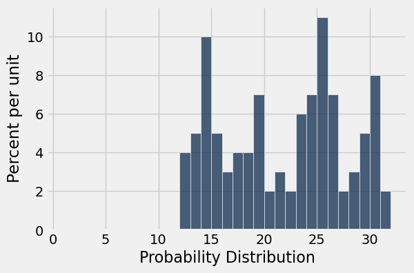

```python
# We suggest using these bins.
roll_bins = np.arange(1, modifier+2+20, 1)
modified_rolls = Table().with_columns("Probability Distribution",simulate_observations(modifier,100))
modified_rolls
modified_rolls.hist(bins = roll_bins)
```

### Estimate the modifier

Now let's imagine we don't know the modifier and try to estimate it from observations. One straightforward (but clearly suboptimal) way to do that is to find the smallest total roll, since the smallest roll on a 20-sided die is 1, which is roughly 0. Use a random number for *modifier* to start and keep this value through the next questions. We will also generate 100 rolls based on the below unknown modifier.  
**Question 1.5** Using that method, estimate modifier from observations. Name your estimate min_estimate.

```python
modifier = np.random.randint(1,20) # Generates a random integer modifier from 1 to 20 inclusive
num_observations = 100
observations = simulate_observations(modifier, num_observations)
observations
min_estimate = min(observations)-1
min_estimate
```

```
10.0
```

```python
check('tests/q1.5.py')
```

All tests passed!

## Estimate the modifier based on the mean of observations.

**Question 1.6** Figure out a good estimate based on that quantity. Then, write a function named mean_based_estimator that computes your estimate. It should take an array of modified rolls (like the array observations) as its argument and return an estimate (single number)of the modifier based on those numbers contianed in the array.

```python
def mean_based_estimator(obs):
    """Estimate the roll modifier based on observed modified rolls in the array nums."""
    mean_based_observations= np.mean(obs)
    expected_roll = 10.5
    mean_based_estimate = mean_based_observations - expected_roll
    return mean_based_estimate

# Here is an example call to your function.  It computes an estimate
# of the modifier from our  observations.
observations = simulate_observations(modifier, 100)
mean_based_estimate = mean_based_estimator(observations)
print(mean_based_estimate)
```

```
10.26
```

```python
check('tests/q1.6.py')
```

All tests passed!

**Question 1.7** Construct a histogram and compare to above estimates, are they consistent? What is your best estimate of the random modifier based on the above, without examining the value?

They are consistent because the estimated modifier of the graph is above 10 as it between 25 and 25.5. The estimated modifier, from above, is 10.26 which is relatively near the estimated value.

```
10.260000000000002
```

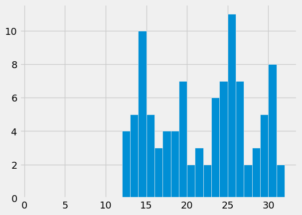

```python
plt.hist(modified_rolls, bins = roll_bins) # Use to plot histogram of an array of 100 modified rolls
estimated_modifier = mean_based_estimate
estimated_modifier
```

```python
check('tests/q1.7.py')
```

All tests passed!

## 2. Sampling and GC content of DNA sequence

DNA within a cell contains codes or sequences for the ultimate synthesis of proteins. In DNA is made up of four types of nucleotides, guanine (G), cytosine (C), adenine (A), and thymine (T) connected in an oredered sequence. These nucleotides on a single strand pair with complimentary nucleotides on a second strand, G pairs with C and A with T. Regions of DNA code for RNA which ultimately directs protein synthesis and these segments are known as genes and these segments often have higher GC content. Hear we will sample 10 nuclotide segments of a DNA sequence and determine the GC content of these DNA segments. See [DNA sequnce basics](http://data-science-sequencing.github.io/Win2018/assets/lecture2/lecture2_2018.pdf) and [GC Content details](https://geneticeducation.co.in/what-is-the-importance-of-gc-content/).

##### Our goal is to sample portions (10 nucelotides) of the sequence and determine the relative content of guanine (G) and cytosine (C) to adenine (A) and thymine (T)

```python
# DNA sequence we will examine, a string
seq = "CGTAACAAGGTTTCCGTAGGTGAACCTGCGGAAGGATCATTGATGAGACCGTGGAATAAACGATCGAGTG \
AATCCGGAGGACCGGTGTACTCAGCTCACCGGGGGCATTGCTCCCGTGGTGACCCTGATTTGTTGTTGGG \
CCGCCTCGGGAGCGTCCATGGCGGGTTTGAACCTCTAGCCCGGCGCAGTTTGGGCGCCAAGCCATATGAA \
AGCATCACCGGCGAATGGCATTGTCTTCCCCAAAACCCGGAGCGGCGGCGTGCTGTCGCGTGCCCAATGA \
ATTTTGATGACTCTCGCAAACGGGAATCTTGGCTCTTTGCATCGGATGGAAGGACGCAGCGAAATGCGAT \
AAGTGGTGTGAATTGCAAGATCCCGTGAACCATCGAGTCTTTTGAACGCAAGTTGCGCCCGAGGCCATCA \
GGCTAAGGGCACGCCTGCTTGGGCGTCGCGCTTCGTCTCTCTCCTGCCAATGCTTGCCCGGCATACAGCC \
AGGCCGGCGTGGTGCGGATGTGAAAGATTGGCCCCTTGTGCCTAGGTGCGGCGGGTCCAAGAGCTGGTGT \
TTTGATGGCCCGGAACCCGGCAAGAGGTGGACGGATGCTGGCAGCAGCTGCCGTGCGAATCCCCCATGTT \
GTCGTGCTTGTCGGACAGGCAGGAGAACCCTTCCGAACCCCAATGGAGGGCGGTTGACCGCCATTCGGAT \
GTGACCCCAGGTCAGGCGGGGGCACCCGCTGAGTTTACGC" # LCBO-Prolactin precursor-Bovine
seq
```

```
'CGTAACAAGGTTTCCGTAGGTGAACCTGCGGAAGGATCATTGATGAGACCGTGGAATAAACGATCGAGTG AATCCGGAGGACCGGTGTACTCAGCTCACCGGGGGCATTGCTCCCGTGGTGACCCTGATTTGTTGTTGGG CCGCCTCGGGAGCGTCCATGGCGGGTTTGAACCTCTAGCCCGGCGCAGTTTGGGCGCCAAGCCATATGAA AGCATCACCGGCGAATGGCATTGTCTTCCCCAAAACCCGGAGCGGCGGCGTGCTGTCGCGTGCCCAATGA ATTTTGATGACTCTC…
```

**Question 2.1A** Run the first two code cells below to see how substrings are extracted and how a character can be counted within a substring. Use the same strategy to determine GC content as fraction of the total in the first 10 nucleotides in the larger sequence above, `seq`

```python
# Example A
samplesize = 4
# Use this short sequence in this example
seq0 = 'GTGAAAGATT'
# How to get a substring
seq0[0:samplesize]
```

```
'GTGA'
```

```python
# Example B
# How to count the number of times 'A' appears in sequence
seq0[0:samplesize].count('A')
```

```
1
```

```python
GCcount = seq[0:10].count('G') + seq[0:10].count('C')
GCcount
GCfraction = GCcount/10
GCfraction
```

```
0.5
```

##### Lists

Below we assemble a list and append an additional entry, 0.7. A useful strategy in creating your function

```python
gc = []
gc.append(0.8)
gc.append(0.7)
gc
```

```
[0.8, 0.7]
```

##### Fill a list with 30 random G, C, T, A nucleotides

use iteration and `np.random.choice`

```python
my_sim_seq = []
nucleo = ['G','C','T','A']
for i in np.arange(30):
    my_sim_seq.append(np.random.choice(nucleo))

print(my_sim_seq)
```

```
['G', 'G', 'T', 'A', 'A', 'G', 'T', 'G', 'G', 'A', 'A', 'G', 'T', 'G', 'C', 'C', 'T', 'G', 'C', 'A', 'A', 'A', 'A', 'A', 'C', 'C', 'A', 'A', 'C', 'C']
```

**Question 2.1B** We will define a function, `calcGC` to do the repetitive work of computing GC content fraction for each segment (samplesize) and return a list with the fraction GC for each `samplesize` segment.

```python
def calcGC(seq, samplesize):
    gc = []
    for i in range(len(seq)-samplesize):
        GCcount = seq[i:i+samplesize].count('G') + seq[i:i+samplesize].count('C')
        GCfraction = GCcount/samplesize
        gc.append(GCfraction)
    return gc
```

```python
check('tests/q2.1.py')
```

All tests passed!

**Question 2.2** Apply this function to our sequence above *seq* with a samplesize of 10. What is the maximum, minimum, mean, and median? (Hint: the max of a list can be obtained with the max(results) and we can use np.mean(results)). Plot the results by using plt.plot(results).

```
0.9
0.1
0.6
0.588783783784
```

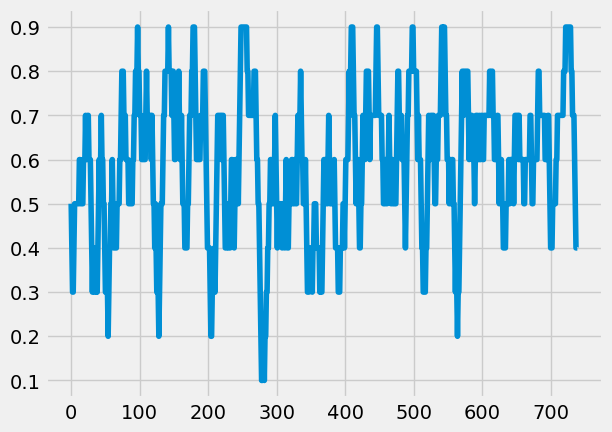

```python
samplesize = 10
results = calcGC(seq,samplesize)
maximum = max(results)
print(maximum)
minimum = min(results)
print(minimum)
median = np.median(results)
print(median)
mean = np.mean(results)
print(mean)

plt.plot(results)
```

```python
check('tests/q2.2.py')
```

All tests passed!

**Question 2.3** Now apply this function to our sequence above *seq* with a different, larger samplesize (>30) of your choosing and plot. What do you observed with the different sampling? What is the maximum, minimum, mean, and median? (Hint: the max of a list can be obtained with the max(results) and we can use np.median(results))

```
0.7
0.43333333333333335
0.6
0.588623188406
```

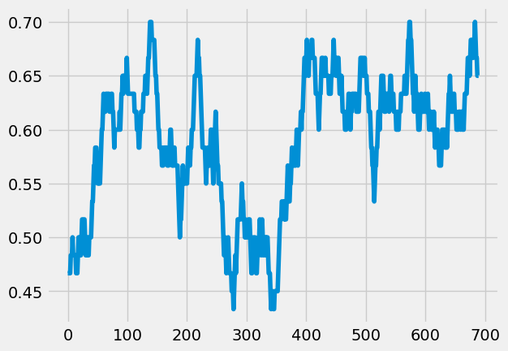

```python
# Plot
samplesize = 60
diffresults = calcGC(seq,samplesize)
maximum = max(diffresults)
print(maximum)
minimum = min(diffresults)
print(minimum)
median = np.median(diffresults)
print(median)
mean = np.mean(diffresults)
print(mean)

plt.plot(diffresults)
```

## 3. Wordle and sampling

Inspired by Medium post: https://ericlani.medium.com/determining-the-best-first-wordle-word-to-guess-using-data-b93b975a6294

#### Letter frequency in sampled texts

We will begin our study by trying to understand the frequency of certain letters by sampling texts. We will again use Charles Darwin's book on the Origin of Species to examine the frequency of letters in this text. To do this we will need to write a function which goes through all the words and determines the counts of letters.

```python
darwin_string = open('data/darwin_origin_species.txt', encoding='utf-8').read()
darwin_words = np.array(darwin_string.split())
darwin_words
```

```
array(['On', 'the', 'Origin', ..., 'stripes', 'on,', '163.'],
      dtype='<U46')
```

**Question 3.1** Define a function to determine letter frequency in text with words split in an array as in above *darwin_words* array and return a Table with letters and their count. We will use a nice trick with a Python dictionary (see: [Python Dictionaries](https://realpython.com/python-dicts/)) as already encoded below.

```python
def letter_freq(words):
    f = {} # Create an empty dictionary to store letters and their count found in words
    for word in words:
        for l in word:
            l = l.lower()
            if l.isalpha(): # avoid punctuation
                f[l] = f.get(l,0) + 1 # Using Python dictionary
    return Table().with_columns('letters',list(f.keys()),'count',list(f.values()))
table = letter_freq(darwin_words)
print(table)
```

```
letters | count
o       | 54301
n       | 54211
t       | 67404
h       | 36780
e       | 99693
r       | 47137
i       | 55682
g       | 13650
f       | 21109
s       | 50943
... (21 rows omitted)
```

Now test your function with your own sentence.

```python
sentence = "Hi, my name is Hannah"
letter_freq(sentence)
```

| letters | count |
| --- | --- |
| h | 3 |
| i | 2 |
| m | 2 |
| y | 1 |
| n | 3 |
| a | 3 |
| e | 1 |
| s | 1 |

```python
check('tests/q3.1.py')
```

All tests passed!

**Question 3.2** Apply the function to the *darwin_string* and examine the output. How many total letters in the text (Hint: use np.sum(freq.column('count')))? Now compute a new column, *frequency* which contains the fraction of each letter. What are the two most frequent letters in this sample?

Two most frequent letters are 'E' and 'T'.

```python
freq = letter_freq(darwin_words).sort("letters")

total_letters = np.sum(freq.column('count')) # How many letters

freq = freq.with_columns("frequency", freq.column("count")/total_letters).sort("frequency",descending=True)
freq
```

| letters | count | frequency |
| --- | --- | --- |
| e | 99693 | 0.132864 |
| t | 67404 | 0.0898312 |
| a | 59475 | 0.079264 |
| i | 55682 | 0.0742089 |
| o | 54301 | 0.0723684 |
| n | 54211 | 0.0722485 |
| s | 50943 | 0.0678931 |
| r | 47137 | 0.0628208 |
| h | 36780 | 0.0490177 |
| l | 31310 | 0.0417277 |

... (21 rows omitted)

```python
check('tests/q3.2.py')
```

All tests passed!

#### Five letter words

**Question 3.3** Now look at a list of 5 letter words assembled by Professor Emeritas Donald Knuth of Stanford. Use your function to determine the letter frequency and compare to above.

```python
from urllib.request import urlopen # Needed to read from internet

url = "https://www-cs-faculty.stanford.edu/~knuth/sgb-words.txt"
knuth5_string=urlopen(url).read().decode('utf-8')
knuth_words = np.array(knuth5_string.split())
```

```python
# Now apply your function and compute letter frequencies
freq = letter_freq(knuth_words).sort("letters")

total_letters = np.sum(freq.column('count'))

freq = freq.with_columns("frequency", freq.column("count")/total_letters).sort("frequency",descending=True)
freq
```

| letters | count | frequency |
| --- | --- | --- |
| s | 3033 | 0.105367 |
| e | 3009 | 0.104534 |
| a | 2348 | 0.0815703 |
| o | 1915 | 0.0665277 |
| r | 1910 | 0.066354 |
| i | 1592 | 0.0553066 |
| l | 1586 | 0.0550981 |
| t | 1585 | 0.0550634 |
| n | 1285 | 0.0446413 |
| d | 1181 | 0.0410283 |

... (16 rows omitted)

```python
check('tests/q3.3.py')
```

All tests passed!

### Compare with Oxford Dictionary

Based on analysis of Oxford dictionary these are the letter frequencies from the dictionary. Compare the three, in the markdown below, what are the similarities?

```python
url = "data/Oxford_Letter_frequency.csv"
letters = Table().read_table(url, header=None, names=["letters","frequency","count"])
letters
```

| letters | frequency | count |
| --- | --- | --- |
| e | 0.111607 | 56.88 |
| a | 0.084966 | 43.31 |
| r | 0.075809 | 38.64 |
| i | 0.075448 | 38.45 |
| o | 0.071635 | 36.51 |
| t | 0.069509 | 35.43 |
| n | 0.066544 | 33.92 |
| s | 0.057351 | 29.23 |
| l | 0.054893 | 27.98 |
| c | 0.045388 | 23.13 |

... (16 rows omitted)

#### Comparsion

When comparing Darwin's Origin of Species, Oxford Dictionary, and Knuth's 5-letter words, the most frequent letter was 'E' for Darwin's Orgin of Species, 'S' for Knuth's 5-letter words, and 'E' for Oxford Dictionry. For Darwin's Origin of Species and Oxford Dictionary, the most used letter was 'E' and the second most used letter for Knuth's was E as well.

**Question 3.4** Let's look at 5-letter words and the frequency of each letter and compare with Oxford case

### Wordle itself

The New York Times hosts [Wordle](https://www.nytimes.com/games/wordle/index.html) where a 5 letter word (Wordle) is determined in six or fewer tries using clues about letters contained and letter position. We will use our new knowledge of letter frequency and Knuth's 5 letter words to come up with best letters and words to try.

```python
# Reload Knuth's words in more convenient pandas format
url = "https://www-cs-faculty.stanford.edu/~knuth/sgb-words.txt"
# Better to read with pandas
import pandas as pd
words_df = pd.read_csv(url, header=None, names=["Words","value","letters"])
```

Now load our letter frequency, *freq*, data table from a chosen text and convert to pandas dataframe.

```python
letters_df = freq.to_df() # Select table from each text above
letters_df
```

|  | letters | count | frequency |
| --- | --- | --- | --- |
| 0 | s | 3033 | 0.105367 |
| 1 | e | 3009 | 0.104534 |
| 2 | a | 2348 | 0.081570 |
| 3 | o | 1915 | 0.066528 |
| 4 | r | 1910 | 0.066354 |
| 5 | i | 1592 | 0.055307 |
| 6 | l | 1586 | 0.055098 |
| 7 | t | 1585 | 0.055063 |
| 8 | n | 1285 | 0.044641 |
| 9 | d | 1181 | 0.041028 |
| 10 | u | 1089 | 0.037832 |
| 11 | c | 964 | 0.033490 |
| 12 | p | 955 | 0.033177 |
| 13 | y | 886 | 0.030780 |
| 14 | m | 843 | 0.029286 |
| 15 | h | 814 | 0.028279 |
| 16 | b | 715 | 0.024839 |
| 17 | g | 679 | 0.023589 |
| 18 | k | 596 | 0.020705 |
| 19 | f | 561 | 0.019489 |
| 20 | w | 505 | 0.017544 |
| 21 | v | 318 | 0.011047 |
| 22 | x | 139 | 0.004829 |
| 23 | z | 135 | 0.004690 |
| 24 | j | 89 | 0.003092 |
| 25 | q | 53 | 0.001841 |

**Question 3.5** Devise a plan to use the collection of letter frequencies and Knuth's five letter words to order the best words to guess for Wordle? Higher letter frequency means more words with the given letter. Describe plan in text markdown only.

##### First, we would need to compute the letter frequency of the five letter words using the letter_freq function. Then, we need to compute the score as the sum of the frequency of each of its letters, using the np.sum function of the number of times the letter is used and then by dividing by the total number of letters in the collection. Then, we would take the highest frequency of given letter and try to guess the best words for Wordle.

#### "Magic" Wordle computation

```python
for index, row in words_df.iterrows():
    prob = 0
    letter_set = set()
    for ele in row['Words']:
        letter_set.add(ele)
        temp_df = letters_df[letters_df["frequency"].where(letters_df["letters"] == ele).notnull()]
        temp_df
        prob += temp_df["frequency"].iloc[0]
        words_df.loc[index, ["value"]] = prob
        words_df.loc[index, ["letters"]] = len(letter_set)

words_df
```

|  | Words | value | letters |
| --- | --- | --- | --- |
| 0 | which | 0.162897 | 4.0 |
| 1 | there | 0.358763 | 4.0 |
| 2 | their | 0.309536 | 5.0 |
| 3 | about | 0.265833 | 5.0 |
| 4 | would | 0.218030 | 5.0 |
| ... | ... | ... | ... |
| 5752 | osier | 0.398089 | 5.0 |
| 5753 | roble | 0.317353 | 5.0 |
| 5754 | rumba | 0.239882 | 5.0 |
| 5755 | biffy | 0.149904 | 4.0 |
| 5756 | pupal | 0.240855 | 4.0 |

5757 rows × 3 columns

Four letter words are included now we will select only five letter words.

```python
words_df.where(words_df["letters"]==5.0).sort_values(by='value',ascending=False).dropna()
```

|  | Words | value | letters |
| --- | --- | --- | --- |
| 697 | arose | 0.424353 | 5.0 |
| 329 | raise | 0.413132 | 5.0 |
| 772 | arise | 0.413132 | 5.0 |
| 3522 | aloes | 0.413097 | 5.0 |
| 5043 | stoae | 0.413062 | 5.0 |
| ... | ... | ... | ... |
| 4681 | humpf | 0.148063 | 5.0 |
| 5180 | mujik | 0.146222 | 5.0 |
| 4949 | whump | 0.146118 | 5.0 |
| 3006 | junky | 0.137051 | 5.0 |
| 2214 | jumpy | 0.134167 | 5.0 |

3834 rows × 3 columns

**Question 3.6**

### Complete and tally your score.

Submit .html and .ipynb of completed laboratory

```python
# For your convenience, you can run this cell to run all the tests at once!
import glob
from gofer.ok import check
correct = 0
total = 11
checks = ['1.1','1.2', '1.3', '1.5', '1.6', '1.7', '2.1', '2.2', '3.1', '3.2','3.3']
for x in checks:
    print('Testing question {}: '.format(x))
    g = check('tests/q{}.py'.format(x))
    if g.grade == 1.0:
        print("Passed")
        correct += 1
    else:
        print('Failed')
        display(g)

print('Grade:  {}'.format(str(correct/total)))
```

```
Testing question 1.1:
Passed
Testing question 1.2:
Passed
Testing question 1.3:
Passed
Testing question 1.5:
Passed
Testing question 1.6:
Passed
Testing question 1.7:
Passed
Testing question 2.1:
Passed
Testing question 2.2:
Passed
Testing question 3.1:
Passed
Testing question 3.2:
Passed
Testing question 3.3:
Passed
Grade:  1.0
```

```python
print(name," Great work!")
```

```
Hannah  Great work!
```